# Lab #5

Jay Maxwell

#### DS202

#### Fall 2020

1. Are there some days of the week where more accidents happen than the others (see FARS manual, use variable DAY_WEEK)?

```r
#load libraries

library(tidyverse)
```

```r
library(ggplot2)
library(readxl)

#remoate data
# acc <- read.csv("https://raw.githubusercontent.com/xdaiISU/ds202materials/master/hwlabs/fars2017/accident.csv", stringsAsFactors = FALSE)
# per <- read.csv("https://raw.githubusercontent.com/xdaiISU/ds202materials/master/hwlabs/fars2017/person.csv", stringsAsFactors = FALSE)

# change from int into to factor & rename the levels
acc$DAY_WEEK <- as.factor(acc$DAY_WEEK)
levels(acc$DAY_WEEK) <- c("Sunday", "Monday", "Tuesday", "Wednesday", "Thursday", "Friday", "Saturday")

acc %>% group_by(DAY_WEEK) %>%
  summarise(acc_count = n()) %>%
  arrange(desc(acc_count))
```

```
## # A tibble: 7 x 2
##   DAY_WEEK  acc_count
##   <fct>         <int>
## 1 Saturday       5873
## 2 Sunday         5360
## 3 Friday         5358
## 4 Thursday       4621
## 5 Monday         4374
## 6 Tuesday        4347
## 7 Wednesday      4314
```

In this dataset, Saturdays are the most frequent days on which accidenets occur.

# Jaeyeon’s revision

- You can also visualize this by acc %>% group_by(DAY_WEEK) %>% summarise(total_acc = n()) %>% ggplot(aes(x = DAY_WEEK, weight = total_acc, fill = DAY_WEEK)) + geom_bar() + ggtitle(‘Barplot of Total Number of Accidents in 2017’) + xlab(‘Day’) + ylab(‘Total Number of Accidents’) + labs(fill = ‘Day’)
2. Create a data frame containing the persons who are fatally hurt in the accidents (look up variable INJ_SEV)

```r
per_fatal <- per %>% filter(INJ_SEV==4)

str(per_fatal)
```

```
## 'data.frame':    37133 obs. of  68 variables:
##  $ STATE     : int  1 1 1 1 1 1 1 1 1 1 ...
##  $ ST_CASE   : int  10001 10002 10003 10004 10005 10006 10007 10008 10009 10011 ...
##  $ VE_FORMS  : int  1 1 3 1 1 2 2 1 1 2 ...
##  $ VEH_NO    : int  1 1 2 1 1 1 1 1 1 1 ...
##  $ PER_NO    : int  1 1 1 1 1 1 1 1 1 1 ...
##  $ STR_VEH   : int  0 0 0 0 0 0 0 0 0 0 ...
##  $ COUNTY    : int  73 89 101 73 13 49 73 3 87 87 ...
##  $ DAY       : int  19 14 31 1 1 6 11 11 11 15 ...
##  $ MONTH     : int  2 2 1 1 1 1 1 1 1 1 ...
##  $ HOUR      : int  23 14 20 16 20 18 17 16 14 4 ...
##  $ MINUTE    : int  35 59 31 55 0 40 57 50 30 35 ...
##  $ RUR_URB   : int  2 2 2 2 1 1 2 1 1 2 ...
##  $ FUNC_SYS  : int  1 1 1 4 1 1 1 1 1 1 ...
##  $ HARM_EV   : int  38 1 12 30 35 34 12 35 21 12 ...
```

[output cut: 54 more lines]

3. Create a data frame containing the most dangerous vehicle make in each state. The number of persons fatally hit in the vehicle make is used to assess the (non-)safety of a make. Make sure to handle the missing values appropriately. (look up variable MAKE)

```r
dangerous <- per_fatal %>%
  filter(!is.na(MAKE)) %>%
  group_by(STATE, MAKE) %>%
  summarise(acc_count = n()) %>%
  group_by(STATE) %>% filter(acc_count == max(acc_count))
dangerous
```

```
## # A tibble: 54 x 3
## # Groups:   STATE [51]
##    STATE  MAKE acc_count
##    <int> <int>     <int>
##  1     1    12       138
##  2     2    12         9
##  3     4    20        88
##  4     5    20        88
##  5     6    49       351
##  6     8    12        63
##  7     8    37        63
##  8     9    37        28
##  9    10    37        12
## 10    11    37         5
## # ... with 44 more rows
```

If I were to refactor and put new levels into all the states and car makes, the above would show you the state name and the most dangerous vehicle in that state. For reference, (12) ford, (20) chrevrolte (49) toyota (37) honda Are different makes in the top of the states. That is not suprising, as those are all large comapnies with high vehicle counts all across the country.

4. Create a map, and label each state with the most dangerous vehicle. Discuss the definition of the most dangerous vehicle, and what you find from the map. (Hint: Read the description for the STATE and COUNTY columns in the FARS manual. The state & county codes are Geographic Locator Codes (GLCs) from the General Services Administration’s (GSA) publication. Use readxl::read_xlsx to read in the GLCs.)

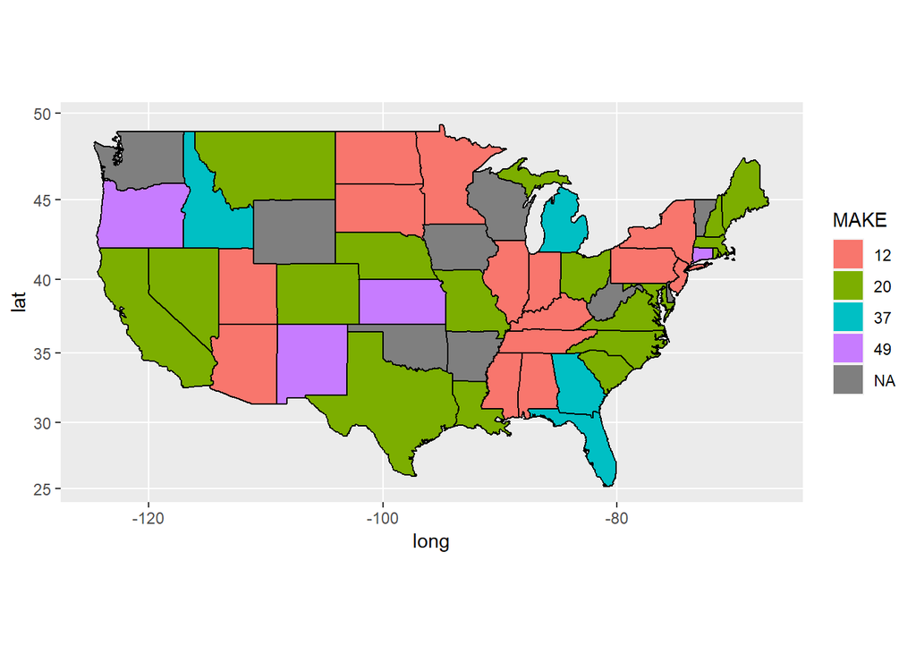

```r
us = map_data('state')
glc = read_xlsx('FRPP_GLC_-_United_StatesSep292020.xlsx')
dangerous$MAKE <- as.factor(dangerous$MAKE)
glc2 <- glc %>%
  rename(state_code = `State Code`, state_name=`State Name`) %>%
  mutate(state_name = tolower(state_name)) %>%
  select(state_code, state_name)



us2 <- us %>% left_join(dangerous, by=c("group" = "STATE"))


us2 %>% ggplot(aes(x=long,y=lat, fill=MAKE)) + geom_polygon(aes(group=group)) + geom_path(aes(group=group), color="black") + coord_map()
```

```r
state_label_locations <- us %>% group_by(group) %>% summarise(long=mean(long),lat=mean(lat))
```

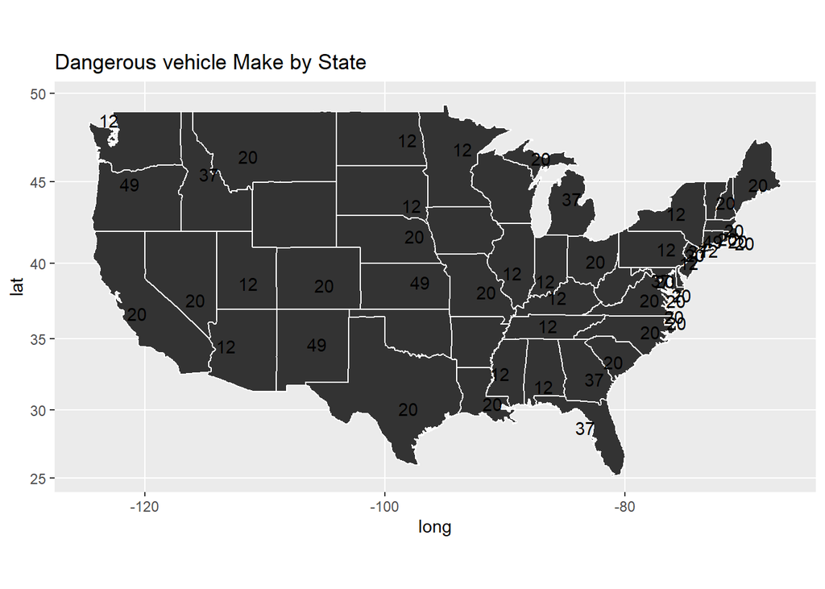

```r
danger_labels <- glc2 %>% mutate(state_code = as.numeric(state_code)) %>%
  left_join(dangerous, by=c("state_code" = "STATE")) %>%
  left_join(us, by = c("state_name" = "region")) %>%
  distinct(state_code, state_name, MAKE, acc_count) %>%
  filter(!(MAKE == 12 & state_code==8)) %>%
  filter(!(MAKE==12 & state_code==34)) %>%
  filter(!(MAKE==37 & state_code==50)) %>%
  left_join(state_label_locations, by = c("state_code" = "group"))





us2 <- us %>% left_join(dangerous, by=c("group" = "STATE"))


us2 %>% ggplot(aes(x=long,y=lat)) + geom_polygon(aes(group=group)) + geom_path(aes(group=group), color="white") + coord_map() + geom_text(data=danger_labels, aes(x=long, y=lat, label=MAKE)) + ggtitle("Dangerous vehicle Make by State")
```

I am not sure where the NAs are coming from….

From our analysys a few steps earlier, the most dangerous vehicle is regarded as the vehicle make in each state which has been involved in the highest count of fatal collisions.

5. Join the accident and person table (work out which variable(s) to use)

```r
big_table <- acc %>% select(DAY_WEEK, HOUR, STATE) %>% left_join(per %>% select(STATE, SEX), by='STATE')

str(big_table)
```

```
## 'data.frame':    126642479 obs. of  4 variables:
##  $ DAY_WEEK: Factor w/ 7 levels "Sunday","Monday",..: 1 1 1 1 1 1 1 1 1 1 ...
##  $ HOUR    : int  23 23 23 23 23 23 23 23 23 23 ...
##  $ STATE   : int  1 1 1 1 1 1 1 1 1 1 ...
##  $ SEX     : int  1 1 1 1 1 1 2 1 2 2 ...
```

6. Tally the number of accidents by day of the week (DAY_WEEK), hour of the day (HOUR) and gender (SEX). Visualize the results.

```r
tally <- big_table %>% group_by(DAY_WEEK, HOUR, SEX) %>%
  summarise(n=n()) %>%
  arrange(DAY_WEEK)
tally
```

```
## # A tibble: 700 x 4
## # Groups:   DAY_WEEK, HOUR [175]
##    DAY_WEEK  HOUR   SEX      n
##    <fct>    <int> <int>  <int>
##  1 Sunday       0     1 817314
##  2 Sunday       0     2 408921
##  3 Sunday       0     8   3760
##  4 Sunday       0     9  19626
##  5 Sunday       1     1 776970
##  6 Sunday       1     2 390056
##  7 Sunday       1     8   2996
##  8 Sunday       1     9  18507
##  9 Sunday       2     1 924705
## 10 Sunday       2     2 462916
## # ... with 690 more rows
```

7. Now plot a choropleth map of the number of deaths on a county level.

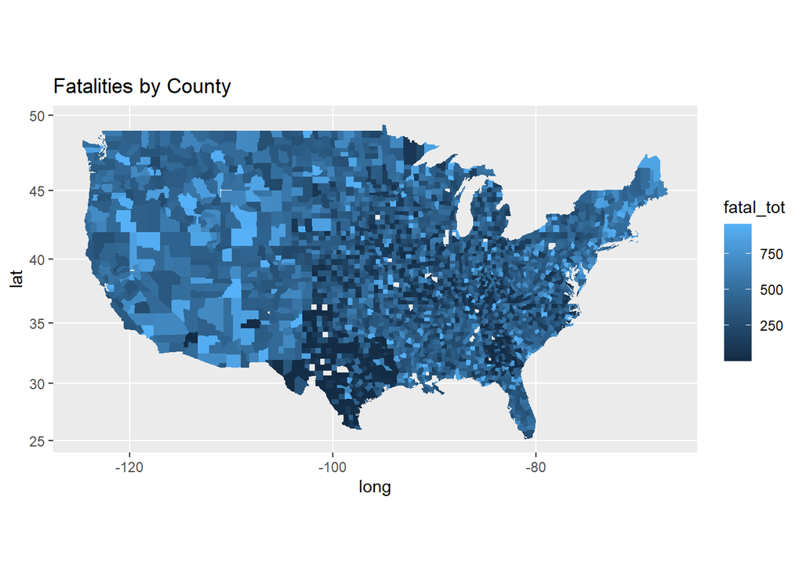

```r
us = map_data('state')
counties <- map_data('county')
glc7 = read_xlsx('FRPP_GLC_-_United_StatesSep292020.xlsx')
glc7 %>%
  rename(county_code = `County Code`, county_name=`County Name`, state_name=`State Name`) %>%
  mutate(county_code = as.numeric(county_code),
         state_name = tolower(state_name),
         county_name = tolower(county_name)) %>%
  select(county_code, county_name, state_name) -> glc8


fatal_acc <- acc %>%
  group_by(COUNTY) %>%
  summarise(fatal_tot = sum(FATALS)) %>%
  left_join(glc8, by =c('COUNTY' = 'county_code')) %>%
  unique()
g <- fatal_acc %>%
  left_join(counties, by =c("county_name" = "subregion", "state_name"="region")) %>%
  ggplot(aes(x = long, y = lat, fill=fatal_tot))  + geom_polygon(aes(group = group)) + ggtitle("Fatalities by County") + coord_map()
g
```

8. Is summer or winter more dangerous? Does this depend on states? Explore and explain.

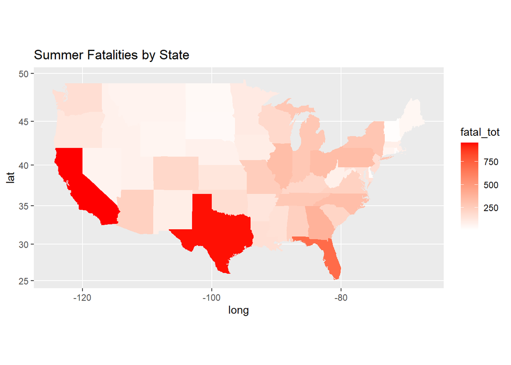

```r
us = map_data('state')
glc = read_xlsx('FRPP_GLC_-_United_StatesSep292020.xlsx')
glc8 <- glc %>%
  rename(state_code = `State Code`, state_name=`State Name`) %>%
  mutate(state_name = tolower(state_name),
         state_code = as.numeric(state_code)) %>%
  select(state_code, state_name)

summer_fatal2 <- acc %>%
  filter(MONTH %in% c(6,7,8)) %>%
  group_by(STATE) %>%
  summarise(fatal_tot = sum(FATALS)) %>%
  left_join(glc8, by = c("STATE" = "state_code")) %>%
  unique()
us8 <- us %>% left_join(summer_fatal2, by=c("region" = "state_name"))


us8 %>%
ggplot(aes(x = long, y = lat, fill=fatal_tot))  +
  geom_polygon(aes(group = group)) + ggtitle("Summer Fatalities by State") + coord_map() +  scale_fill_gradient(low = "white", high = "red")
```

```r
winter_fatal2 <- acc %>%
  filter(MONTH %in% c(12,2,1)) %>%
  group_by(STATE) %>%
  summarise(fatal_tot = sum(FATALS)) %>%
  left_join(glc8, by = c("STATE" = "state_code")) %>%
  unique()
```

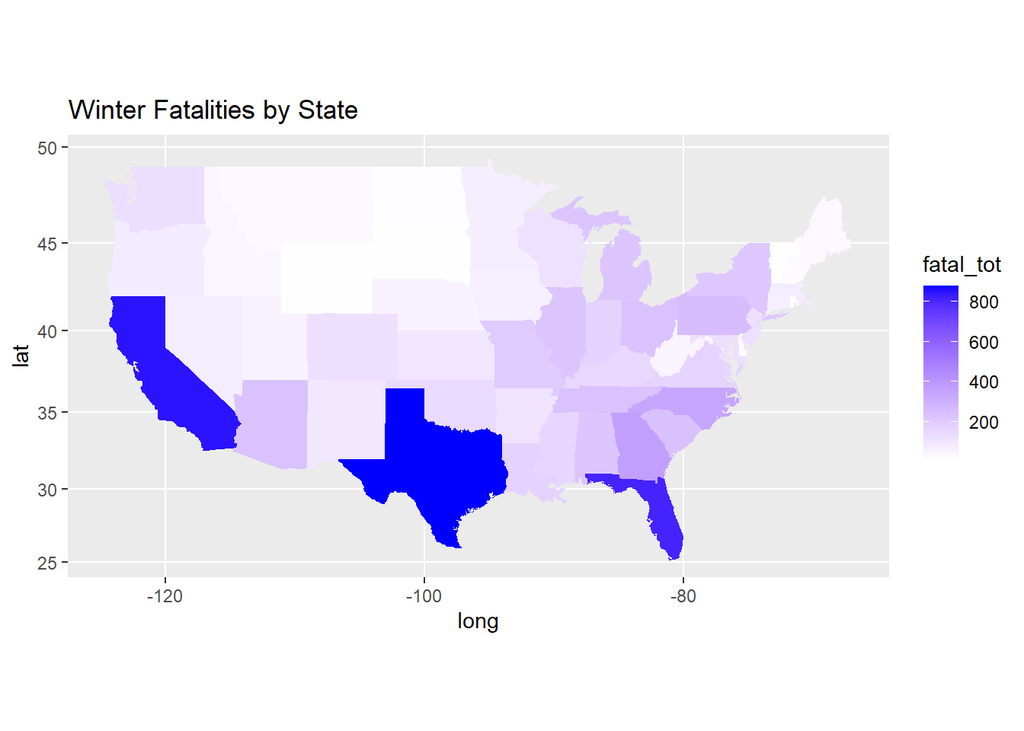

```r
us %>% left_join(winter_fatal2, by=c("region" = "state_name")) %>%
  ggplot(aes(x = long, y = lat, fill=fatal_tot))  +
  geom_polygon(aes(group = group)) + ggtitle("Winter Fatalities by State") + coord_map() +  scale_fill_gradient(low = "white", high = "blue")
```

No matter the season, Florida, California and Texas have the highest number of fatal accidents. That should not be surprising, as they have high populations and receive a lot of visitor traffic.